# Titanic survival prediction

BSHT Michielsen MSc

This notebook aims at predicting the survivability of people who were on the titanic during its disasterous sinking by applying decision trees. The main advantage of decision trees is that humans can easily understand and reproduce the sequence of decisions taken by the model to predict the target, which makes it one of the most transparent machine learning algorithms available.

[figure not shown]

```python
import sklearn
import pandas
import seaborn

print("scikit-learn version:", sklearn.__version__)     # 1.1.3
print("pandas version:", pandas.__version__)            # 1.5.1
print("seaborn version:", seaborn.__version__)          # 0.12.1
```

```
scikit-learn version: 1.3.0
pandas version: 2.1.0
seaborn version: 0.12.2
```

# 📦 Data provisioning

After loading the data from the csv file, it is immediately apparent that the dataset contains a large number of missing values. This notebook is an example on training a decision tree, and not on resolving data quality issues. Nevertheless a little bit of fixing is needed to make it work. Thus, the rather destructive approach of simply removing the features `pnumber`, `name`, `home.dest` and `ticket` is taken, as well as simply filling the missing values of `age` by its mean. Surely there are perhaps better ways to handle the missing data in `age` but they are outside the scope of this example.

```python
df = pandas.read_csv("Titanic.csv")
df.sample(5)
```

|  | pnumber | pclass | survived | name | age | embarked | home.dest | room | ticket | boat | sex |
| --- | --- | --- | --- | --- | --- | --- | --- | --- | --- | --- | --- |
| 1089 | 1090 | 3rd | 0 | Olsen, Mr Ole M. | NaN | NaN | NaN | NaN | NaN | NaN | male |
| 849 | 850 | 3rd | 0 | Hansen, Mr Henry Damsgaard | NaN | NaN | NaN | NaN | NaN | NaN | male |
| 595 | 596 | 2nd | 1 | Williams, Mr Charles Eugene | NaN | Southampton | Harrow, England | NaN | NaN | 14 | male |
| 360 | 361 | 2nd | 0 | Campbell, Mr William | NaN | NaN | Belfast | NaN | NaN | NaN | male |
| 1081 | 1082 | 3rd | 1 | Odahl, Mr Nils Martin | NaN | NaN | NaN | NaN | NaN | NaN | male |

```python
df = df.drop(["pnumber", "name", "home.dest", "ticket"], axis=1)
df["age"] =  df["age"].fillna(df["age"].mean())
```

## 📃 Sample the data

A random sample of 5 observations from the data after the data provisioning.

```python
df.sample(5)
```

|  | pclass | survived | age | embarked | room | boat | sex |
| --- | --- | --- | --- | --- | --- | --- | --- |
| 718 | 3rd | 0 | 29.000000 | Southampton | NaN | NaN | male |
| 69 | 1st | 1 | 39.000000 | Cherbourg | NaN | 14 | female |
| 457 | 2nd | 1 | 31.194181 | Southampton | NaN | NaN | female |
| 1312 | 3rd | 0 | 31.194181 | NaN | NaN | NaN | male |
| 85 | 1st | 1 | 31.194181 | Southampton | NaN | 7-May | female |

# Preprocessing

## 🆔 Encoding

The features `pclass` and `sex` are currently categorical, but can fairly easily be mapped to integers because `sex` is binary and therefore can be encoded using `0` and `1`. Whereas `class` is ordinal, first class is better than second class and third class, so the integers `1`, `2` and `3` make sense.

```python
df["pclass"] = df["pclass"].map({"1st":1, "2nd":2, "3rd":3}).astype(int)
df["sex"] = df["sex"].map({"male":0, "female":1}).astype(int)
df.sample(5)
```

|  | pclass | survived | age | embarked | room | boat | sex |
| --- | --- | --- | --- | --- | --- | --- | --- |
| 1207 | 3 | 1 | 31.194181 | NaN | NaN | NaN | 1 |
| 951 | 3 | 0 | 31.194181 | NaN | NaN | NaN | 0 |
| 1064 | 3 | 0 | 31.194181 | NaN | NaN | NaN | 0 |
| 877 | 3 | 0 | 31.194181 | NaN | NaN | NaN | 0 |
| 326 | 2 | 0 | 34.000000 | Southampton | NaN | NaN | 0 |

The feature `embarked` is categorical too, but it is a little harder to turn into an integer because the values are not binary and neither ordinal (none of the values is better than another in any sense). Therefore, a different approach is needed. Given that only one value is ever true (a passenger could not have embarked both of two different places) the approach of [one-hot](https://en.wikipedia.org/wiki/One-hot) encoding will suffice here. The pandas function named `get_dummies` can be used for this. The result is that the dataset now has three new features with names equal to the values of the `embarked` column and in just one of them there is a `1` which indicates the place in which the passenger embarked. Note that the fact that sometimes `embarked` is missing is ignored, and this approach will simply put `0` in every one of the three new features, which is technically wrong.

```python
df = pandas.concat([df, pandas.get_dummies(df["embarked"])], axis=1)
df = df.drop("embarked", axis=1)
df.sample(5)
```

|  | pclass | survived | age | room | boat | sex | Cherbourg | Queenstown | Southampton |
| --- | --- | --- | --- | --- | --- | --- | --- | --- | --- |
| 1148 | 3 | 0 | 31.194181 | NaN | NaN | 1 | False | False | False |
| 117 | 1 | 1 | 49.000000 | NaN | 5 | 0 | True | False | False |
| 29 | 1 | 0 | 31.194181 | D-21/2 | NaN | 0 | False | False | True |
| 137 | 1 | 0 | 31.194181 | NaN | NaN | 0 | False | False | True |
| 327 | 2 | 1 | 32.000000 | NaN | NaN | 1 | False | False | True |

The features `room` and `boat` are dropped instead of being encoded, because in the case of `room` it is hard to turn it into a numeric value that is actually useful for the machine to train on. The room number itself is probably useless, however, the distance from the room to a lifeboat might actually have been an interesting feature. However, without a map of the titanic, this distance cannot be inferred from the room number. The case of `boat` is different because `survived` and `boat` are not independent. In order to survive you need to have reached a lifeboat, so any value in the `boat` feature is highly likely to result in having survived the disaster. However, a conclusion like "If you were in a life boat, you are likely to have survived." is rather trivial. Therefore `boat` becomes a feature that is not going to be selected anyway. Note that for legibility reasons the target is moved to the end of the data set.

```python
df = df[["pclass", "sex", "age", "Cherbourg", "Queenstown", "Southampton", "survived"]]
df.sample(5)
```

|  | pclass | sex | age | Cherbourg | Queenstown | Southampton | survived |
| --- | --- | --- | --- | --- | --- | --- | --- |
| 245 | 1 | 0 | 32.000000 | True | False | False | 1 |
| 1170 | 3 | 1 | 31.194181 | False | False | False | 0 |
| 438 | 2 | 1 | 31.194181 | False | False | True | 1 |
| 1105 | 3 | 0 | 31.194181 | False | False | False | 0 |
| 399 | 2 | 1 | 31.194181 | True | False | False | 1 |

## 💡 Feature selection

A heatmap will be used to select a suitable set of features to predict the `survived` target upon.

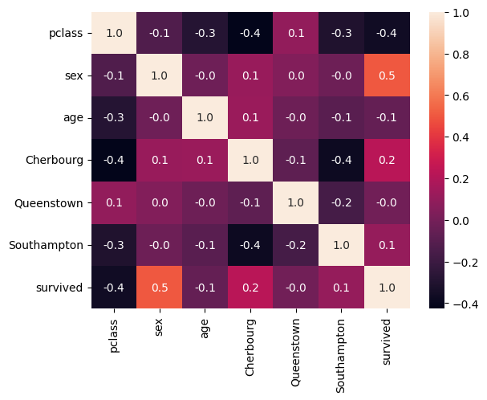

```python
correlations = df.corr()
plot = seaborn.heatmap(correlations, cbar=True, annot=True, fmt=".1f")
```

Apparently the class of the ticket and the sex of the passenger are most indicative for survivability. Since we choose the value `1` for female and `0` for male, the correlation coefficient of positive `0.5` indicates that when the value for `sex` goes up, survivability also goes up, so females have a higher chance to survive than males. Similarly when the value for `pclass` goes up (and therefore the class goes down, because 1st class is higher than 3rd class) survivability goes down, in other words, 1st class passenger were more likely to survive than other classes. Additionally, passengers that embarked in Cherbourg seem to have a little higher survivability too, which is not easily explained. Surprisingly however, the age does have little influence, which is unexpected because the consensus in case of disaster of that time was that women and children are to be saved first. This is probably why `sex` does correlate well with `survived`, as mentioned before, but does not explain why `age` does not correlate well.

For now, no investigation into age is undertaken but merely the features `pclass`, `sex` and `Cherbourg` are selected to continue.

```python
features = ["pclass", "sex", "Cherbourg"]
target = "survived"

X = df[features]
y = df[target]
```

## 🪓 Splitting into train/test

```python
from sklearn.model_selection import train_test_split
X_train, X_test, y_train, y_test = train_test_split(X, y, test_size=.2)
print("There are in total", len(X), "observations, of which", len(X_train), "are now in the train set, and", len(X_test), "in the test set.")
```

```
There are in total 1313 observations, of which 1050 are now in the train set, and 263 in the test set.
```

# Modelling

```python
from sklearn.tree import DecisionTreeClassifier
model = DecisionTreeClassifier()
model.fit(X_train, y_train)
score = model.score(X_test, y_test)
print("Accuracy:", score)
```

```
Accuracy: 0.8365019011406845
```

It is possible to ask the decision tree which features it considers import in deciding the outcome and which features it considers less import. The values are fractions which add up to 100%.

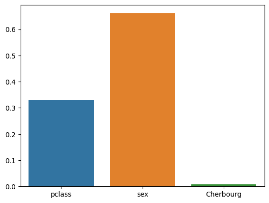

```python
plot = seaborn.barplot(y=model.feature_importances_, x=features)
```

As expected the feature `sex` has the greatest influence (~65%) on the decision that the tree will take, followed by the feature `pclass` (~33%). The feature `Cherbourg` has very little influence and it is perhaps better eliminated as to reduce the complexity of the model.

The biggest advantage of using a decision tree is that the tree itself can be drawn as to give insight in what actually happens inside the tree. For humans this is an understandable process that greatly improves the transparency of the modelling step.

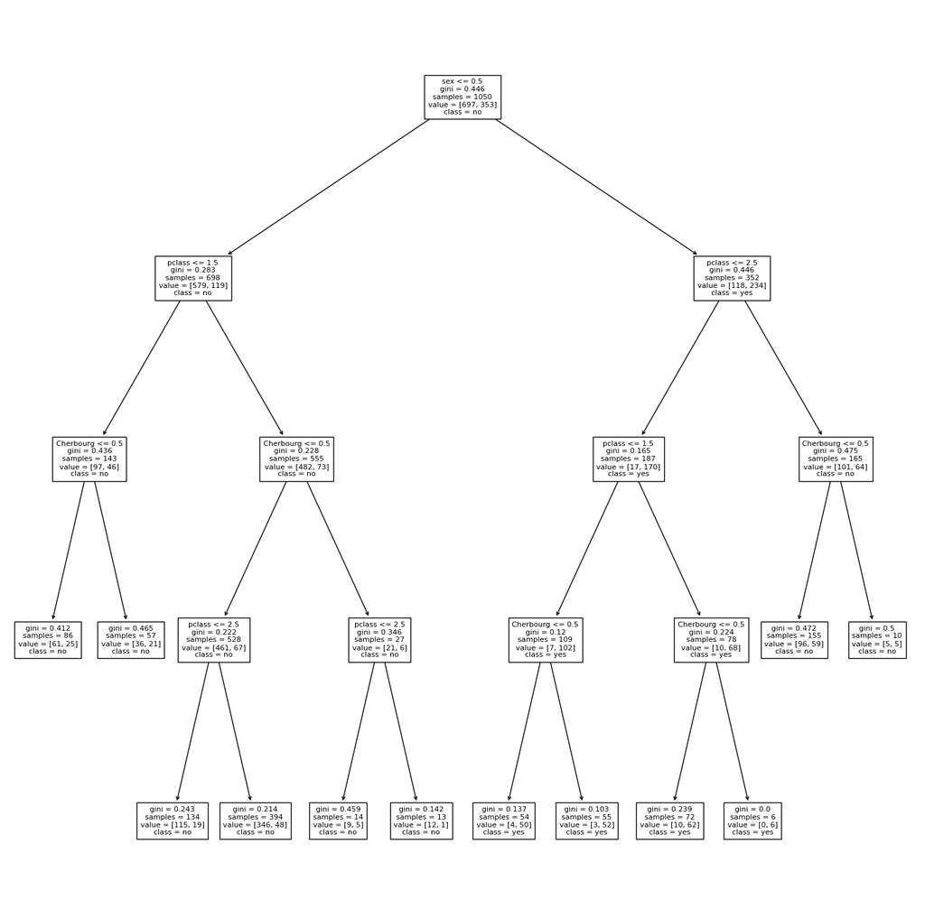

```python
target_names = ["no", "yes"]
import matplotlib.pyplot as plt
plt.figure(figsize=(18,18))
from sklearn.tree import plot_tree
plot_tree(model, fontsize=8, feature_names=features, class_names=target_names)
plt.show()
```

# Evaluation

This notebook produces slightly different results every time it is ran due to the random train/test split. However, calculating the evaluation metrics for the train set as well as the test set gives us insight in whether the model is overfitted or not. If the trainset results are a lot better than the testset results, it means that the model is trained a little too well on the train set and therefore generalizes badly in the real world.

```python
from sklearn.metrics import classification_report

print("Train set:")
predictions = model.predict(X_train)
report = classification_report(y_train, predictions, target_names=target_names)
print(report)

print("Test set:")
predictions = model.predict(X_test)
report = classification_report(y_test, predictions, target_names=target_names)
print(report)
```

```
Train set:
              precision    recall  f1-score   support

          no       0.79      0.98      0.87       697
         yes       0.91      0.48      0.63       353

    accuracy                           0.81      1050
   macro avg       0.85      0.73      0.75      1050
weighted avg       0.83      0.81      0.79      1050

Test set:
              precision    recall  f1-score   support

          no       0.81      0.97      0.88       167
         yes       0.92      0.60      0.73        96

    accuracy                           0.84       263
   macro avg       0.87      0.79      0.81       263
weighted avg       0.85      0.84      0.83       263
```

Running the notebook a few times one will notice that sometimes the results for the testset are a little different from the trainset, but not greatly so. In conclusion, the model is not overfitted and will generalize well in the real world.

# Inference

Now let us try a few fictionally persons, and see whether they would have survived the Titanic Disaster or not.

First class female, not from Cherbourg.

```python
data = {"pclass": 1, "sex": 1, "Cherbourg": 0}

X_inference = pandas.DataFrame([data])
prediction = model.predict_proba(X_inference)
result = pandas.DataFrame()
result["Outcome"] = target_names
result["Probability"] = prediction[0]
result
```

|  | Outcome | Probability |
| --- | --- | --- |
| 0 | no | 0.074074 |
| 1 | yes | 0.925926 |

Second class male, from Cherbourg.

```python
data = {"pclass": 2, "sex": 0, "Cherbourg": 1}

X_inference = pandas.DataFrame([data])
prediction = model.predict_proba(X_inference)
result = pandas.DataFrame()
result["Outcome"] = target_names
result["Probability"] = prediction[0]
result
```

|  | Outcome | Probability |
| --- | --- | --- |
| 0 | no | 0.642857 |
| 1 | yes | 0.357143 |

First class male, from Cherbourg.

```python
data = {"pclass": 1, "sex": 0, "Cherbourg": 1}

X_inference = pandas.DataFrame([data])
prediction = model.predict_proba(X_inference)
result = pandas.DataFrame()
result["Outcome"] = target_names
result["Probability"] = prediction[0]
result
```

|  | Outcome | Probability |
| --- | --- | --- |
| 0 | no | 0.631579 |
| 1 | yes | 0.368421 |

# Exercises

## Model complexity

### Make a new model without the feature 'Cherbourg'

```python
features = ["pclass", "sex"]
target = "survived"

X = df[features]
y = df[target]
```

```python
X_train, X_test, y_train, y_test = train_test_split(X, y, test_size=.2)
print("There are in total", len(X), "observations, of which", len(X_train), "are now in the train set, and", len(X_test), "in the test set.")
```

```
There are in total 1313 observations, of which 1050 are now in the train set, and 263 in the test set.
```

```python
model = DecisionTreeClassifier()
model.fit(X_train, y_train)
score = model.score(X_test, y_test)
print("Accuracy:", score)
```

```
Accuracy: 0.8250950570342205
```

```python
data = {"pclass": 1, "sex": 1}

X_inference = pandas.DataFrame([data])
prediction = model.predict_proba(X_inference)
result = pandas.DataFrame()
result["Outcome"] = target_names
result["Probability"] = prediction[0]
result
```

|  | Outcome | Probability |
| --- | --- | --- |
| 0 | no | 0.068376 |
| 1 | yes | 0.931624 |

## Iris

### Apply a Decision Tree to this data set in order to have it classify iris plants.

```python
columns = ["Sepal Length", "Sepal Width", "Petal Length", "Petal Width", "Species"]
df = pandas.read_csv("http://archive.ics.uci.edu/ml/machine-learning-databases/iris/iris.data", names=columns)
df.shape
print(df)
```

```
     Sepal Length  Sepal Width  Petal Length  Petal Width         Species
0             5.1          3.5           1.4          0.2     Iris-setosa
1             4.9          3.0           1.4          0.2     Iris-setosa
2             4.7          3.2           1.3          0.2     Iris-setosa
3             4.6          3.1           1.5          0.2     Iris-setosa
4             5.0          3.6           1.4          0.2     Iris-setosa
..            ...          ...           ...          ...             ...
145           6.7          3.0           5.2          2.3  Iris-virginica
146           6.3          2.5           5.0          1.9  Iris-virginica
147           6.5          3.0           5.2          2.0  Iris-virginica
148           6.2          3.4           5.4          2.3  Iris-virginica
149           5.9          3.0           5.1          1.8  Iris-virginica

[150 rows x 5 columns]
```

```python
from sklearn import preprocessing
encoder = preprocessing.LabelEncoder()
df["Species ID"] = encoder.fit_transform(df["Species"])
```

```python
features = ["Petal Length", "Petal Width"]
target = "Species ID"
X = df[features]
y = df[target]
```

```python
X_train, X_test, y_train, y_test = train_test_split(X, y, test_size=0.2)
print("There are in total", len(X), "observations, of which", len(X_train), "are now in the train set, and", len(X_test), "in the test set.")
model = DecisionTreeClassifier()
model.fit(X_train, y_train)
score = model.score(X_test, y_test)
```

```
There are in total 150 observations, of which 120 are now in the train set, and 30 in the test set.
```

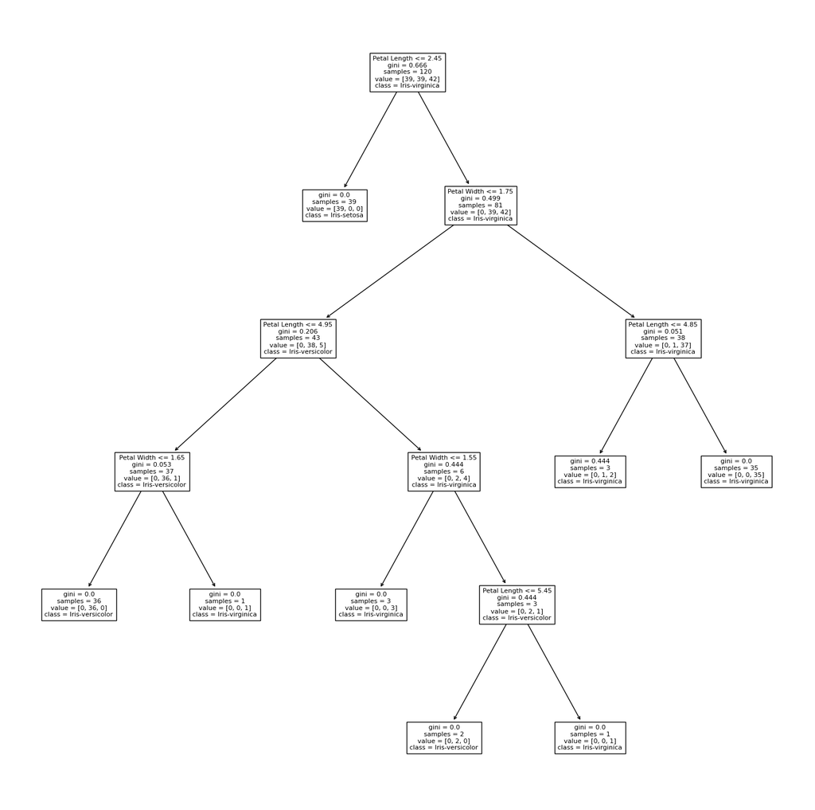

```python
target_names = ["Iris-setosa", "Iris-versicolor", "Iris-virginica"]
import matplotlib.pyplot as plt
plt.figure(figsize=(18,18))
from sklearn.tree import plot_tree
plot_tree(model, fontsize=8, feature_names=features, class_names=target_names)
plt.show()
```

In the first step, the drawn tree already recognizes the Iris-setosa. After this step, multiple small steps are performed to differentiate the Iris-versicolor and the Iris-virginica. You could argue that this part is somewhat overfitted since they make multiple small steps.

## Hyperparameters

### Set the parameters `max_depth`, `min_samples_split` and `min_samples_leaf` to something different than their default

```
There are in total 150 observations, of which 120 are now in the train set, and 30 in the test set.
```

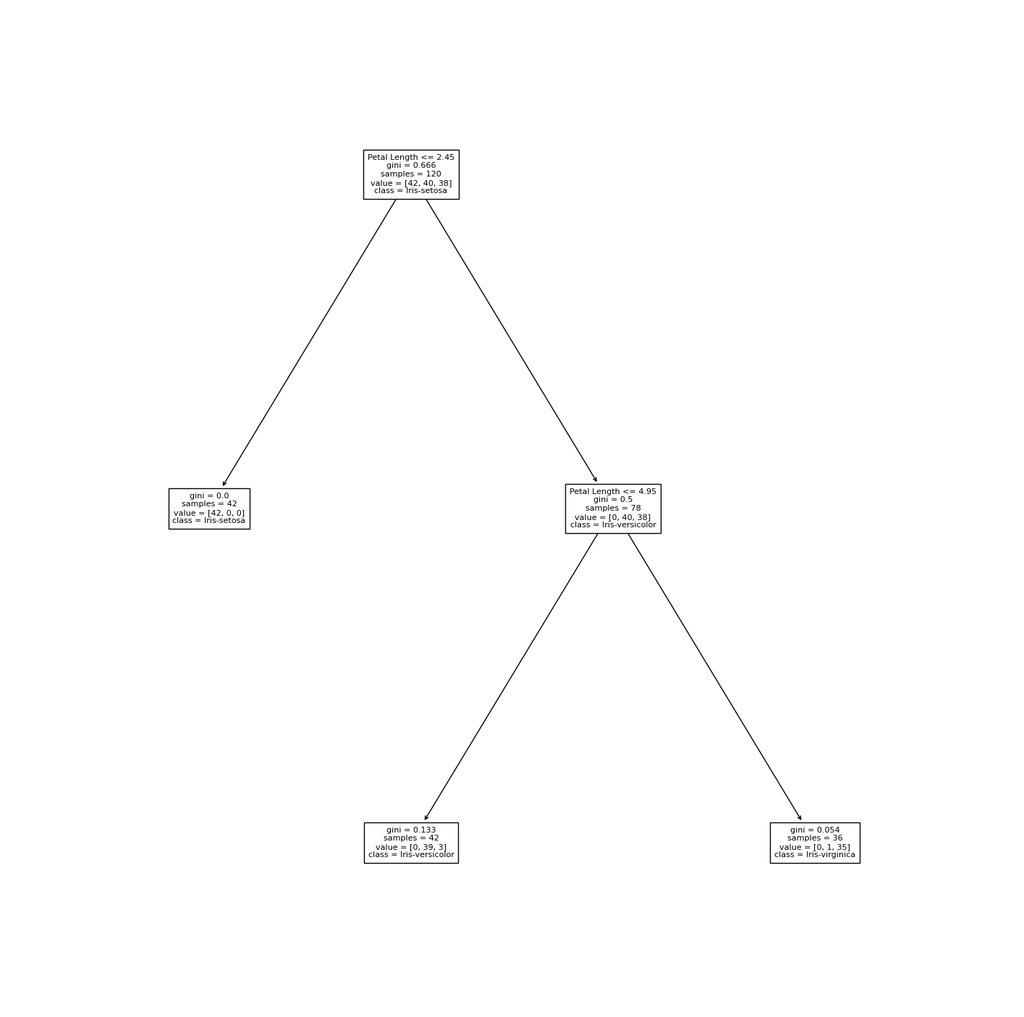

```python
X_train, X_test, y_train, y_test = train_test_split(X, y, test_size=0.2)
print("There are in total", len(X), "observations, of which", len(X_train), "are now in the train set, and", len(X_test), "in the test set.")
model = DecisionTreeClassifier(max_depth=2)
model.fit(X_train, y_train)
score = model.score(X_test, y_test)
target_names = ["Iris-setosa", "Iris-versicolor", "Iris-virginica"]
import matplotlib.pyplot as plt
plt.figure(figsize=(18,18))
from sklearn.tree import plot_tree
plot_tree(model, fontsize=8, feature_names=features, class_names=target_names)
plt.show()
```

### max_depth

The max_depth value is how much steps the tree can make. If you set this value to 2, you make 2 steps to determine the class.

```
There are in total 150 observations, of which 120 are now in the train set, and 30 in the test set.
```

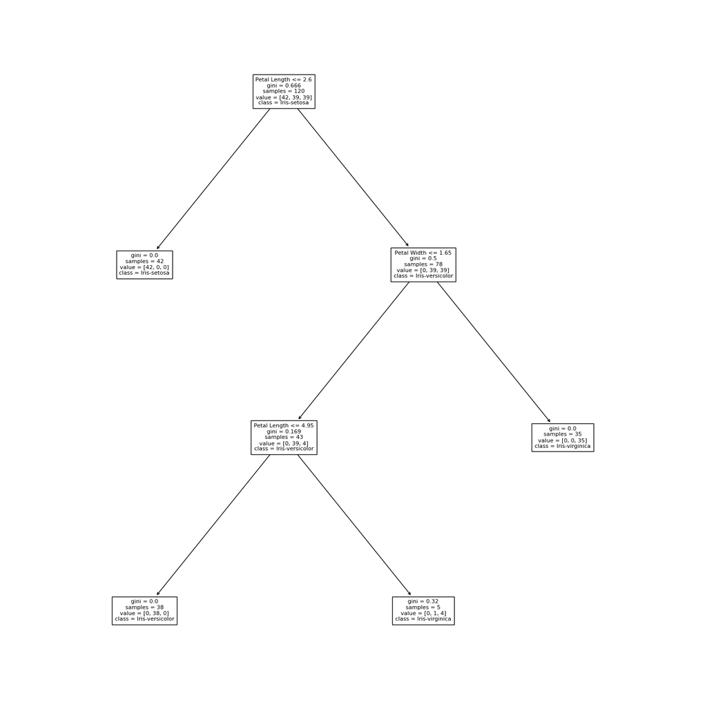

```python
X_train, X_test, y_train, y_test = train_test_split(X, y, test_size=0.2)
print("There are in total", len(X), "observations, of which", len(X_train), "are now in the train set, and", len(X_test), "in the test set.")
model = DecisionTreeClassifier(min_samples_split=30)
model.fit(X_train, y_train)
score = model.score(X_test, y_test)
target_names = ["Iris-setosa", "Iris-versicolor", "Iris-virginica"]
import matplotlib.pyplot as plt
plt.figure(figsize=(18,18))
from sklearn.tree import plot_tree
plot_tree(model, fontsize=8, feature_names=features, class_names=target_names)
plt.show()
```

### min_sample_split

The min_sample_split parameter defines what the minimal sample size should be to make another step. Lets say I set this value to 30, then if my sample size is 29 (<30), it is not able to make another step.

```
There are in total 150 observations, of which 120 are now in the train set, and 30 in the test set.
```

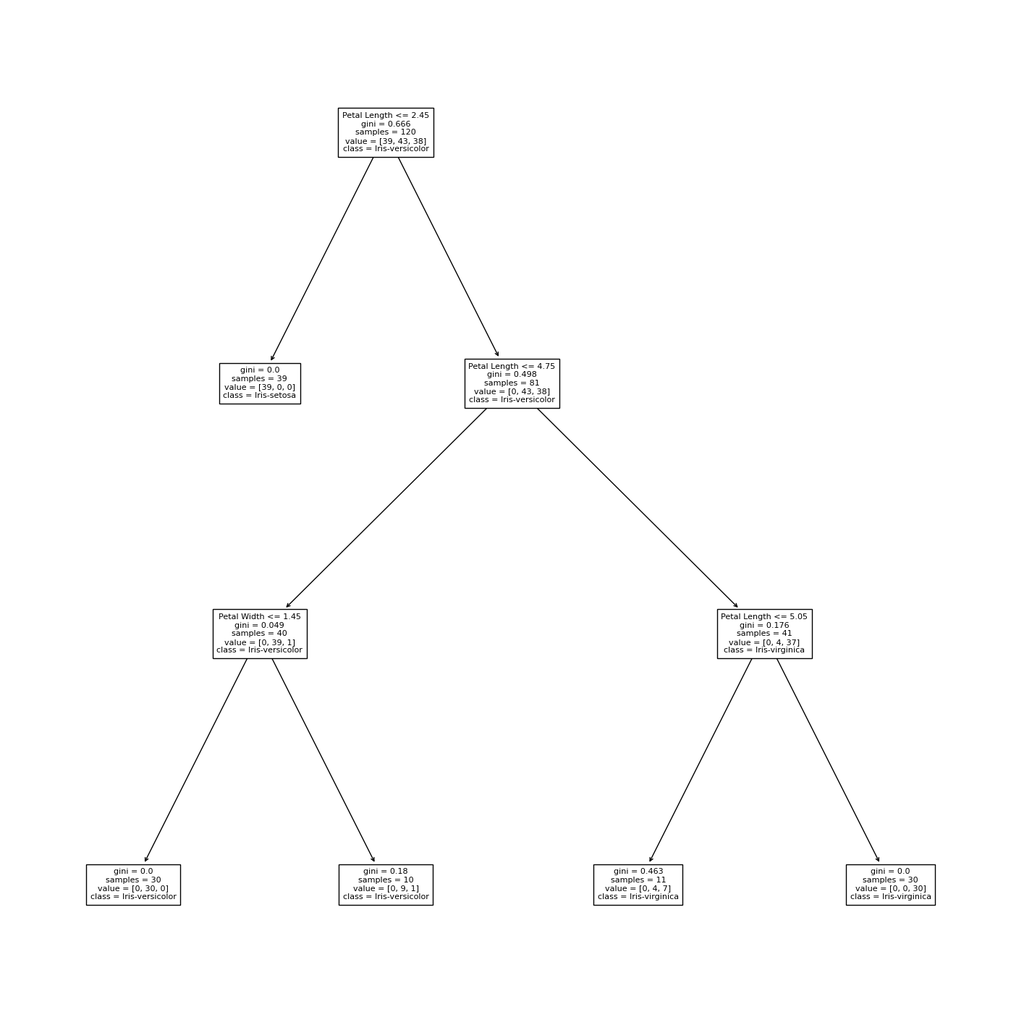

```python
X_train, X_test, y_train, y_test = train_test_split(X, y, test_size=0.2)
print("There are in total", len(X), "observations, of which", len(X_train), "are now in the train set, and", len(X_test), "in the test set.")
model = DecisionTreeClassifier(min_samples_leaf=10)
model.fit(X_train, y_train)
score = model.score(X_test, y_test)
target_names = ["Iris-setosa", "Iris-versicolor", "Iris-virginica"]
import matplotlib.pyplot as plt
plt.figure(figsize=(18,18))
from sklearn.tree import plot_tree
plot_tree(model, fontsize=8, feature_names=features, class_names=target_names)
plt.show()
```

### min_samples_leaf

The min_samples_leaf determines how much the minimum number of samples are requred in a leaf of the tree. So let's say the next step would devide the sample size between 6 and 21, the step would not be made if min_samples_leaf > 6.

## What do you believe is the ultimate goal of this?

I think the ultimate goal of adjusting these values is to get high accuracy. You should not make it overfitted, because the model would not work that good on predictions unlike your trainingset.

## Evaluation

Matthijs Dolmans evaluated my hyperparameters exercise. These are his comments: The explanation is right.